# Web Scraping

Biostat 203B

Author

Dr. Hua Zhou @ UCLA

Published

February 9, 2024

Load tidyverse and other packages for this lecture.

```r
library("tidyverse")
library("rvest")
library("quantmod")
```

## 1 Web scraping

There is a wealth of data on internet. How to scrape them and analyze them?

## 2 rvest

rvest is an R package written by Hadley Wickham which makes web scraping easy.

## 3 Example: Scraping from webpage

- We follow instructions in a [Blog by SAURAV KAUSHIK](https://www.analyticsvidhya.com/blog/2017/03/beginners-guide-on-web-scraping-in-r-using-rvest-with-hands-on-knowledge/) to find the most popular feature films of 2020.
- Install the SelectorGadget by dragging the link to your bookmark.
- The 100 most popular feature films released in 2020 can be accessed at page https://www.imdb.com/search/title/?title_type=feature&release_date=2020-01-01,2020-12-31&count=100.

```r
# Specifying the url for desired website to be scraped
url <- "https://www.imdb.com/search/title/?title_type=feature&release_date=2020-01-01,2020-12-31&count=100"
# Reading the HTML code from the website
(webpage <- read_html(url))
```

```
{html_document}
<html lang="en-US" xmlns:og="http://opengraphprotocol.org/schema/" xmlns:fb="http://www.facebook.com/2008/fbml">
[1] <head>\n<meta http-equiv="Content-Type" content="text/html; charset=UTF-8 ...
[2] <body>\n<div>    <img height="1" width="1" style="display:none;visibility ...
```

[figure not shown]

### 3.1 Rank and title

- Use SelectorGadget to find the CSS selector `.ipc-title-link-wrapper .ipc-title__text`.

```r
# Using CSS selectors to scrap the title section
(title_data_html <- html_nodes(webpage, '.ipc-title-link-wrapper .ipc-title__text'))
```

```
{xml_nodeset (100)}
 [1] <h3 class="ipc-title__text">1. The Postcard Killings</h3>
 [2] <h3 class="ipc-title__text">2. Promising Young Woman</h3>
 [3] <h3 class="ipc-title__text">3. 365 Days</h3>
 [4] <h3 class="ipc-title__text">4. Arkansas</h3>
 [5] <h3 class="ipc-title__text">5. Tenet</h3>
 [6] <h3 class="ipc-title__text">6. The Nest</h3>
 [7] <h3 class="ipc-title__text">7. Greyhound</h3>
 [8] <h3 class="ipc-title__text">8. The Hunt</h3>
 [9] <h3 class="ipc-title__text">9. Hamilton</h3>
[10] <h3 class="ipc-title__text">10. The Dry</h3>
[11] <h3 class="ipc-title__text">11. Greenland</h3>
[12] <h3 class="ipc-title__text">12. Another Round</h3>
[13] <h3 class="ipc-title__text">13. Soul</h3>
[14] <h3 class="ipc-title__text">14. The Devil All the Time</h3>
[15] <h3 class="ipc-title__text">15. The Father</h3>
[16] <h3 class="ipc-title__text">16. Birds of Prey</h3>
[17] <h3 class="ipc-title__text">17. Emma.</h3>
[18] <h3 class="ipc-title__text">18. Sonic the Hedgehog</h3>
[19] <h3 class="ipc-title__text">19. After We Collided</h3>
[20] <h3 class="ipc-title__text">20. Love and Monsters</h3>
...
```

```r
# Converting the title data to text
(ranktitle_data <- html_text(title_data_html))
```

```
  [1] "1. The Postcard Killings"
  [2] "2. Promising Young Woman"
  [3] "3. 365 Days"
  [4] "4. Arkansas"
  [5] "5. Tenet"
  [6] "6. The Nest"
  [7] "7. Greyhound"
  [8] "8. The Hunt"
  [9] "9. Hamilton"
 [10] "10. The Dry"
 [11] "11. Greenland"
 [12] "12. Another Round"
 [13] "13. Soul"
 [14] "14. The Devil All the Time"
 [15] "15. The Father"
```

[output cut: 85 more lines]

```r
# rank
rank_data <- str_extract(ranktitle_data, "^[0-9]+") |> as.integer() |> print()
```

```
  [1]   1   2   3   4   5   6   7   8   9  10  11  12  13  14  15  16  17  18
 [19]  19  20  21  22  23  24  25  26  27  28  29  30  31  32  33  34  35  36
 [37]  37  38  39  40  41  42  43  44  45  46  47  48  49  50  51  52  53  54
 [55]  55  56  57  58  59  60  61  62  63  64  65  66  67  68  69  70  71  72
 [73]  73  74  75  76  77  78  79  80  81  82  83  84  85  86  87  88  89  90
 [91]  91  92  93  94  95  96  97  98  99 100
```

```r
# title
title_data <- str_remove(ranktitle_data, "^[0-9]+. ") |> print()
```

```
  [1] "The Postcard Killings"
  [2] "Promising Young Woman"
  [3] "365 Days"
  [4] "Arkansas"
  [5] "Tenet"
  [6] "The Nest"
  [7] "Greyhound"
  [8] "The Hunt"
  [9] "Hamilton"
 [10] "The Dry"
 [11] "Greenland"
 [12] "Another Round"
 [13] "Soul"
 [14] "The Devil All the Time"
 [15] "The Father"
```

[output cut: 85 more lines]

### 3.2 Description

```r
# Using CSS selectors to scrap the description section
(description_data_html <- html_nodes(webpage, '.ipc-html-content-inner-div'))
```

```
{xml_nodeset (100)}
 [1] <div class="ipc-html-content-inner-div">A New York detective investigate ...
 [2] <div class="ipc-html-content-inner-div">A young woman, traumatized by a  ...
 [3] <div class="ipc-html-content-inner-div">Massimo is a member of the Sicil ...
 [4] <div class="ipc-html-content-inner-div">Kyle and Swin live by the orders ...
 [5] <div class="ipc-html-content-inner-div">Armed with only one word, Tenet, ...
 [6] <div class="ipc-html-content-inner-div">Life for an entrepreneur and his ...
 [7] <div class="ipc-html-content-inner-div">Several months after the U.S. en ...
 [8] <div class="ipc-html-content-inner-div">Twelve strangers wake up in a cl ...
 [9] <div class="ipc-html-content-inner-div">The real life of one of America' ...
[10] <div class="ipc-html-content-inner-div">Aaron Falk returns to his drough ...
[11] <div class="ipc-html-content-inner-div">A family struggles for survival  ...
[12] <div class="ipc-html-content-inner-div">Four high-school teachers consum ...
[13] <div class="ipc-html-content-inner-div">After landing the gig of a lifet ...
[14] <div class="ipc-html-content-inner-div">Sinister characters converge aro ...
[15] <div class="ipc-html-content-inner-div">A man refuses all assistance fro ...
[16] <div class="ipc-html-content-inner-div">After splitting with the Joker,  ...
[17] <div class="ipc-html-content-inner-div">In 1800s England, a well meaning ...
[18] <div class="ipc-html-content-inner-div">After discovering a small, blue, ...
[19] <div class="ipc-html-content-inner-div">Based on the 2014 romance novel  ...
[20] <div class="ipc-html-content-inner-div">Seven years after he survived th ...
...
```

```r
# Converting the description data to text
description_data <- html_text(description_data_html)
# take a look at first few
head(description_data)
```

```
[1] "A New York detective investigates the death of his daughter who was murdered while on her honeymoon in London; he recruits the help of a Scandinavian journalist when other couples throughout Europe suffer a similar fate."
[2] "A young woman, traumatized by a tragic event in her past, seeks out vengeance against those who crossed her path."
[3] "Massimo is a member of the Sicilian Mafia family and Laura is a sales director. She does not expect that on a trip to Sicily trying to save her relationship, Massimo will kidnap her and give her 365 days to fall in love with him."
[4] "Kyle and Swin live by the orders of an Arkansas-based drug kingpin named Frog, whom they've never met. But when a deal goes horribly wrong, the consequences are deadly."
[5] "Armed with only one word, Tenet, and fighting for the survival of the entire world, a Protagonist journeys through a twilight world of international espionage on a mission that will unfold in something beyond real time."
[6] "Life for an entrepreneur and his American family begins to take a twisted turn after moving into an English country manor."
```

### 3.3 Runtime

- Retrieve runtime strings

```r
# Using CSS selectors to scrap the Movie runtime section
runtime_text <- webpage |>
  html_nodes('.dli-title-metadata-item:nth-child(2)') |>
  html_text() |>
  print()
```

```
  [1] "1h 44m" "1h 53m" "1h 54m" "1h 57m" "2h 30m" "1h 47m" "1h 31m" "1h 30m"
  [9] "2h 40m" "1h 57m" "1h 59m" "1h 57m" "1h 40m" "2h 18m" "1h 37m" "1h 49m"
 [17] "2h 4m"  "1h 39m" "1h 45m" "1h 49m" "1h 31m" "1h 30m" "2h 3m"  "1h 58m"
 [25] "2h 14m" "1h 47m" "2h 5m"  "1h 35m" "1h 36m" "1h 38m" "1h 56m" "1h 37m"
 [33] "1h 55m" "2h 4m"  "1h 34m" "2h 31m" "1h 30m" "1h 49m" "2h 6m"  "1h 29m"
 [41] "2h 17m" "1h 34m" "1h 40m" "1h 55m" "1h 33m" "1h 52m" "1h 17m" "1h 42m"
 [49] "1h 52m" "2h 2m"  "2h 3m"  "1h 56m" "2h 9m"  "1h 46m" "1h 41m" "1h 43m"
 [57] "1h 42m" "1h 51m" "2h 4m"  "1h 58m" "2h 3m"  "1h 26m" "1h 30m" "2h 4m"
 [65] "1h 33m" "1h 30m" "1h 47m" "1h 35m" "1h 37m" "1h 35m" "2h"     "1h 47m"
 [73] "2h 11m" "1h 49m" "1h 28m" "2h 16m" "1h 35m" "1h 35m" "1h 45m" "1h 43m"
 [81] "1h 40m" "1h 56m" "1h 40m" "1h 35m" "1h 56m" "1h 58m" "1h 27m" "1h 59m"
 [89] "1h 30m" "1h 57m" "1h 36m" "1h 51m" "1h 41m" "1h 49m" "1h 57m" "1h 53m"
 [97] "1h 33m" "1h 53m" "1h 39m" "1h 38m"
```

- Hours and minutes:

```r
# hours
runtime_hour <- runtime_text |>
  str_extract("\\d+(?=h)") |>
  as.integer() |>
  print()
```

```
  [1] 1 1 1 1 2 1 1 1 2 1 1 1 1 2 1 1 2 1 1 1 1 1 2 1 2 1 2 1 1 1 1 1 1 2 1 2 1
 [38] 1 2 1 2 1 1 1 1 1 1 1 1 2 2 1 2 1 1 1 1 1 2 1 2 1 1 2 1 1 1 1 1 1 2 1 2 1
 [75] 1 2 1 1 1 1 1 1 1 1 1 1 1 1 1 1 1 1 1 1 1 1 1 1 1 1
```

```r
# minutes
runtime_min <- runtime_text |>
  str_extract("\\d+(?=m)") |>
  # replace NA by 0
  str_replace_na("0") |>
  as.integer() |>
  print()
```

```
  [1] 44 53 54 57 30 47 31 30 40 57 59 57 40 18 37 49  4 39 45 49 31 30  3 58 14
 [26] 47  5 35 36 38 56 37 55  4 34 31 30 49  6 29 17 34 40 55 33 52 17 42 52  2
 [51]  3 56  9 46 41 43 42 51  4 58  3 26 30  4 33 30 47 35 37 35  0 47 11 49 28
 [76] 16 35 35 45 43 40 56 40 35 56 58 27 59 30 57 36 51 41 49 57 53 33 53 39 38
```

- Runtime in minutes

```r
runtime_data <- (runtime_hour * 60 + runtime_min) |> print()
```

```
  [1] 104 113 114 117 150 107  91  90 160 117 119 117 100 138  97 109 124  99
 [19] 105 109  91  90 123 118 134 107 125  95  96  98 116  97 115 124  94 151
 [37]  90 109 126  89 137  94 100 115  93 112  77 102 112 122 123 116 129 106
 [55] 101 103 102 111 124 118 123  86  90 124  93  90 107  95  97  95 120 107
 [73] 131 109  88 136  95  95 105 103 100 116 100  95 116 118  87 119  90 117
 [91]  96 111 101 109 117 113  93 113  99  98
```

### 3.4 Film rating

- Film rating:

```r
filmrating_data <- webpage |>
  html_nodes('.dli-title-metadata-item:nth-child(3)') %>%
  html_text() |>
  str_replace("Unrated", "Not Rated") |>
  print()
```

```
  [1] "Not Rated" "R"         "TV-MA"     "R"         "PG-13"     "R"
  [7] "PG-13"     "R"         "PG-13"     "R"         "PG-13"     "Not Rated"
 [13] "PG"        "R"         "PG-13"     "R"         "PG"        "PG"
 [19] "R"         "PG-13"     "PG"        "R"         "PG-13"     "R"
 [25] "R"         "R"         "R"         "PG-13"     "R"         "R"
 [31] "R"         "PG-13"     "PG-13"     "R"         "Not Rated" "PG-13"
 [37] "PG-13"     "TV-MA"     "R"         "R"         "R"         "PG-13"
 [43] "PG"        "PG-13"     "R"         "PG-13"     "Not Rated" "PG"
 [49] "TV-MA"     "PG-13"     "PG-13"     "Not Rated" "R"         "PG"
 [55] "PG"        "R"         "R"         "R"         "R"         "PG-13"
 [61] "PG-13"     "R"         "TV-MA"     "TV-MA"     "R"         "R"
 [67] "PG"        "Not Rated" "R"         "PG"        "PG-13"     "R"
 [73] "R"         "PG-13"     "R"         "R"         "Not Rated" "R"
 [79] "R"         "PG-13"     "PG"        "Not Rated" "TV-MA"     "Not Rated"
 [85] "R"         "PG-13"     "PG-13"     "PG"        "Not Rated" "R"
 [91] "R"         "TV-MA"     "TV-MA"     "PG-13"     "TV-MA"     "R"
 [97] "R"         "R"         "Not Rated" "TV-MA"
```

### 3.5 Votes

- Vote data

```r
votes_data <- webpage |>
  html_nodes('.cPpOqU') |>
  html_text() |>
  str_remove("Votes") |>
  str_remove(",") |>
  as.numeric() |>
  print()
```

```
  [1]  14773 207750  97303  14677 579532  17658 111867 126710 110869  31996
 [11] 130963 190323 372388 150567 187570 261927  61465 156777  37501 143110
 [21]  28179 179394 215377 144000  98611 180085 181328  95466  61911  26367
 [31] 258912 267260  94833 251474   3374 289146  93941  26829  55611  29743
 [41]  37468  88080  55663 157830  32942  72092  31838 167311  42391    718
 [51] 101354  61975 191339  46055  70390  44851  71040  96540 173184  88598
 [61]  46054  17034  44660  36455  25288  75799  17226  15199   5270  52042
 [71]  34551  65665  81926  57227  37437  75873  21830 152043  10619  67178
 [81]  16902  37237  78034   1242  45878  94757  33651   8349  11331  22625
 [91]   7283  18786  49915  83711  70992  96719  24031   8644   1042  46885
```

### 3.6 User rating

- User rating:

```r
userrating_data <- webpage |>
  html_nodes('.ratingGroup--imdb-rating') |>
  html_text() |>
  str_extract("^\\d+\\.\\d+") |>
  as.numeric() |>
  print()
```

```
  [1] 5.8 7.5 3.3 6.0 7.3 6.3 7.0 6.5 8.3 6.9 6.4 7.7 8.0 7.1 8.2 6.1 6.7 6.5
 [19] 5.0 6.9 6.1 7.4 6.6 6.4 6.6 7.3 6.7 5.9 5.5 6.2 6.8 7.2 7.4 7.1 5.6 5.4
 [37] 6.7 6.3 7.0 6.0 6.2 5.3 6.7 5.8 6.3 7.2 7.1 7.4 7.1 6.9 6.5 7.5 7.7 5.4
 [55] 5.6 6.5 6.3 6.2 6.5 5.7 6.0 6.5 5.7 7.1 5.4 6.0 6.5 4.8 4.7 6.9 7.3 6.5
 [73] 6.8 4.9 5.7 7.1 6.1 6.6 6.4 5.2 4.7 5.5 6.8 4.4 6.7 6.8 5.5 6.4 5.7 6.5
 [91] 5.3 5.6 5.8 5.7 8.2 6.0 6.0 5.9 5.4 6.3
```

### 3.7 Metascore

- We encounter the issue of missing data when scraping metascore.
- We see there are only 91 meta scores. 9 movies don’t have meta scores. We may manually find which movies don’t have meta scores but that’s tedious and not reproducible.

```r
# Using CSS selectors to scrap the metascore section
ms_data <- html_nodes(webpage, '.metacritic-score-box') |>
  html_text() |>
  as.integer() |>
  print()
```

```
 [1] 29 72 55 69 80 64 50 88 69 64 79 83 55 88 60 71 47 14 63 51 83 68 66 78 88
[26] 70 48 39 70 56 71 89 72 60 67 13 66 77 43 48 66 65 79 61 50 81 76 47 26 72
[51] 67 49 59 58 46 76 33 46 40 32 22 57 56 59 68 79 22 62 67 72 68 73 47 51 51
[76] 56 38 73 64 41 58 72 37 31 22 44 72 51 54 56 57
```

- First let’s tally title (no missingness) and corresponding metascore (if present).

```r
rank_and_metascore <- webpage |>
  html_nodes('.ipc-title-link-wrapper .ipc-title__text , .metacritic-score-box') |>
  html_text() |>
  # remove anything after the space
  str_remove(" .*") |>
  print()
```

```
  [1] "1."   "29"   "2."   "72"   "3."   "4."   "55"   "5."   "69"   "6."
 [11] "80"   "7."   "64"   "8."   "50"   "9."   "88"   "10."  "69"   "11."
 [21] "64"   "12."  "79"   "13."  "83"   "14."  "55"   "15."  "88"   "16."
 [31] "60"   "17."  "71"   "18."  "47"   "19."  "14"   "20."  "63"   "21."
 [41] "51"   "22."  "83"   "23."  "68"   "24."  "66"   "25."  "78"   "26."
 [51] "88"   "27."  "70"   "28."  "48"   "29."  "39"   "30."  "70"   "31."
 [61] "56"   "32."  "71"   "33."  "89"   "34."  "72"   "35."  "36."  "60"
 [71] "37."  "67"   "38."  "13"   "39."  "66"   "40."  "77"   "41."  "42."
 [81] "43"   "43."  "48"   "44."  "66"   "45."  "46."  "65"   "47."  "79"
 [91] "48."  "61"   "49."  "50."  "51."  "50"   "52."  "81"   "53."  "76"
[101] "54."  "47"   "55."  "26"   "56."  "72"   "57."  "67"   "58."  "49"
[111] "59."  "59"   "60."  "58"   "61."  "46"   "62."  "76"   "63."  "33"
[121] "64."  "65."  "46"   "66."  "40"   "67."  "32"   "68."  "22"   "69."
[131] "57"   "70."  "56"   "71."  "59"   "72."  "68"   "73."  "79"   "74."
[141] "22"   "75."  "62"   "76."  "67"   "77."  "72"   "78."  "68"   "79."
[151] "73"   "80."  "47"   "81."  "51"   "82."  "51"   "83."  "56"   "84."
[161] "85."  "38"   "86."  "73"   "87."  "64"   "88."  "41"   "89."  "58"
[171] "90."  "72"   "91."  "37"   "92."  "31"   "93."  "22"   "94."  "44"
[181] "95."  "72"   "96."  "51"   "97."  "54"   "98."  "56"   "99."  "57"
[191] "100."
```

```r
# logical vector indicating if the element is a rank
isrank <- str_detect(rank_and_metascore, "\\.$")
# a rank followed by another rank is a missing metascore
ismissing <- isrank[1:(length(rank_and_metascore) - 1)] & isrank[2:(length(rank_and_metascore))]
# last entry is missing or not
ismissing[length(ismissing) + 1] <- isrank[length(isrank)]
# which ranks are missing metascore
missingpos <- as.integer(rank_and_metascore[ismissing])
metascore_data <- rep(NA, 100)
metascore_data[-missingpos] <- ms_data |> print()
```

```
 [1] 29 72 55 69 80 64 50 88 69 64 79 83 55 88 60 71 47 14 63 51 83 68 66 78 88
[26] 70 48 39 70 56 71 89 72 60 67 13 66 77 43 48 66 65 79 61 50 81 76 47 26 72
[51] 67 49 59 58 46 76 33 46 40 32 22 57 56 59 68 79 22 62 67 72 68 73 47 51 51
[76] 56 38 73 64 41 58 72 37 31 22 44 72 51 54 56 57
```

### 3.8 Visualizing movie data

- Form a tibble:

```r
# Combining all the lists to form a data frame
movies <- tibble(
  poprank = rank_data,
  title = title_data,
  description = description_data,
  runtime = runtime_data,
  filmrating = filmrating_data,
  userrating = userrating_data,
  metascore = metascore_data,
  votes = votes_data,
) |>
  print(width=Inf)
```

```
# A tibble: 100 × 8
   poprank title
     <int> <chr>
 1       1 The Postcard Killings
 2       2 Promising Young Woman
 3       3 365 Days
 4       4 Arkansas
 5       5 Tenet
 6       6 The Nest
 7       7 Greyhound
 8       8 The Hunt
 9       9 Hamilton
10      10 The Dry
   description
   <chr>
```

[output cut: 23 more lines]

- Top 5 popular movies:

```r
movies |>
  slice_min(order_by = poprank, n = 5) |>
  print(width=Inf)
```

```
# A tibble: 5 × 8
  poprank title
    <int> <chr>
1       1 The Postcard Killings
2       2 Promising Young Woman
3       3 365 Days
4       4 Arkansas
5       5 Tenet
  description
  <chr>
1 A New York detective investigates the death of his daughter who was murdered …
2 A young woman, traumatized by a tragic event in her past, seeks out vengeance…
3 Massimo is a member of the Sicilian Mafia family and Laura is a sales directo…
4 Kyle and Swin live by the orders of an Arkansas-based drug kingpin named Frog…
5 Armed with only one word, Tenet, and fighting for the survival of the entire …
  runtime filmrating userrating metascore  votes
    <dbl> <chr>           <dbl>     <int>  <dbl>
1     104 Not Rated         5.8        29  14773
2     113 R                 7.5        72 207750
3     114 TV-MA             3.3        NA  97303
4     117 R                 6          55  14677
5     150 PG-13             7.3        69 579532
```

- Top 5 user rated movies:

```r
movies |>
  slice_max(order_by = userrating, n = 5) |>
  print(width = Inf)
```

```
# A tibble: 6 × 8
  poprank title
    <int> <chr>
1       9 Hamilton
2      15 The Father
3      95 Demon Slayer: Kimetsu no Yaiba - The Movie: Mugen Train
4      13 Soul
5      12 Another Round
6      53 The Trial of the Chicago 7
  description
  <chr>
1 The real life of one of America's foremost founding fathers and first Secreta…
2 A man refuses all assistance from his daughter as he ages. As he tries to mak…
3 After his family was brutally murdered and his sister turned into a demon, Ta…
4 After landing the gig of a lifetime, a New York jazz pianist suddenly finds h…
5 Four high-school teachers consume alcohol on a daily basis to see how it affe…
6 The story of 7 people on trial stemming from various charges surrounding the …
  runtime filmrating userrating metascore  votes
    <dbl> <chr>           <dbl>     <int>  <dbl>
1     160 PG-13             8.3        88 110869
2      97 PG-13             8.2        88 187570
3     117 TV-MA             8.2        72  70992
4     100 PG                8          83 372388
5     117 Not Rated         7.7        79 190323
6     129 R                 7.7        76 191339
```

- Top 5 meta scores:

```r
movies |>
  slice_max(order_by = metascore, n = 5) |>
  print(width = Inf)
```

```
# A tibble: 6 × 8
  poprank title
    <int> <chr>
1      33 Minari
2       9 Hamilton
3      15 The Father
4      26 Nomadland
5      13 Soul
6      22 Palm Springs
  description
  <chr>
1 A Korean American family moves to an Arkansas farm in search of its own Ameri…
2 The real life of one of America's foremost founding fathers and first Secreta…
3 A man refuses all assistance from his daughter as he ages. As he tries to mak…
4 A woman in her sixties, after losing everything in the Great Recession, embar…
5 After landing the gig of a lifetime, a New York jazz pianist suddenly finds h…
6 Stuck in a time loop, two wedding guests develop a budding romance while livi…
  runtime filmrating userrating metascore  votes
    <dbl> <chr>           <dbl>     <int>  <dbl>
1     115 PG-13             7.4        89  94833
2     160 PG-13             8.3        88 110869
3      97 PG-13             8.2        88 187570
4     107 R                 7.3        88 180085
5     100 PG                8          83 372388
6      90 R                 7.4        83 179394
```

- How many top 100 movies are in each film rating category?

```r
movies %>%
  count(filmrating)
```

```
# A tibble: 5 × 2
  filmrating     n
  <chr>      <int>
1 Not Rated     11
2 PG            12
3 PG-13         25
4 R             42
5 TV-MA         10
```

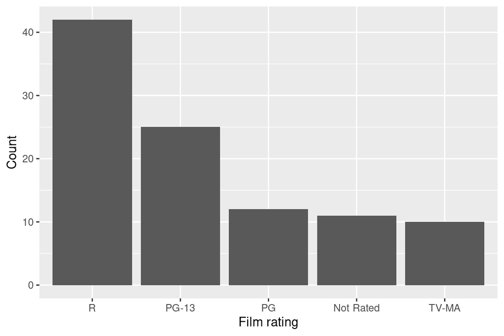

```r
# bar plot
ggplot(data = movies) +
  geom_bar(mapping = aes(x = fct_infreq(filmrating))) +
  labs(y = "count") +
  labs(x = "Film rating", y = "Count")
```

- Is there a relationship between user rating and metascore (critics rating)? How to inform the number of votes? Stratify by film rating?

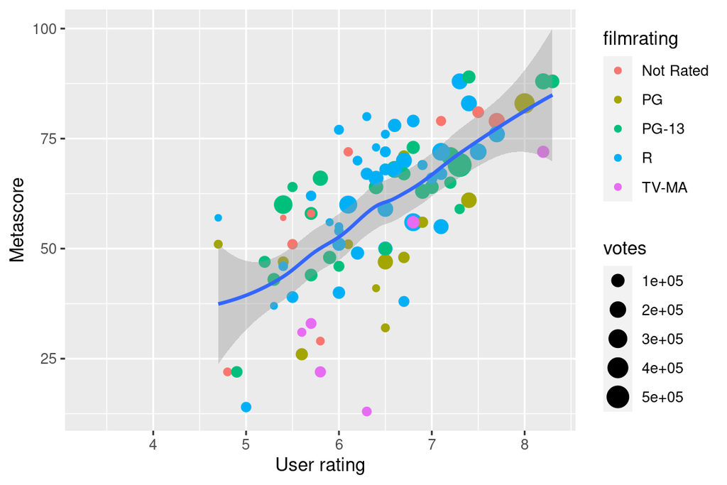

```r
ggplot(data = movies, mapping = aes(x = userrating, y = metascore)) +
  geom_point(mapping = aes(size = votes, color = filmrating)) +
  geom_smooth() +
  labs(y = "Metascore", x = "User rating")
```

## 4 Example: Scraping finance data

- `quantmod` package contains many utility functions for retrieving and plotting finance data. E.g.,

```r
library(quantmod)
stock <- getSymbols("TSLA", src = "yahoo", auto.assign = FALSE, from = "2020-01-01")
head(stock)
```

```
           TSLA.Open TSLA.High TSLA.Low TSLA.Close TSLA.Volume TSLA.Adjusted
2020-01-02  28.30000  28.71333 28.11400   28.68400   142981500      28.68400
2020-01-03  29.36667  30.26667 29.12800   29.53400   266677500      29.53400
2020-01-06  29.36467  30.10400 29.33333   30.10267   151995000      30.10267
2020-01-07  30.76000  31.44200 30.22400   31.27067   268231500      31.27067
2020-01-08  31.58000  33.23267 31.21533   32.80933   467164500      32.80933
2020-01-09  33.14000  33.25333 31.52467   32.08933   426606000      32.08933
```

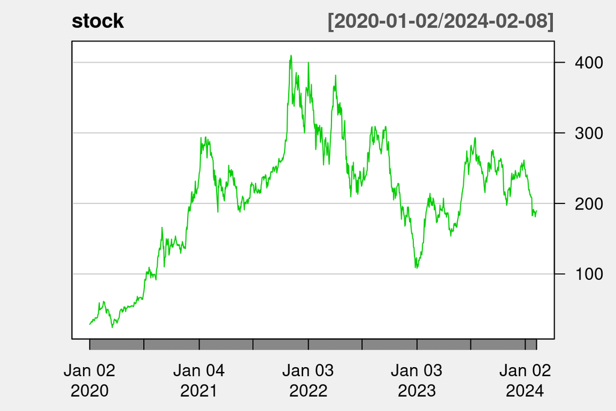

```r
chartSeries(stock, theme = chartTheme("white"),
            type = "line", log.scale = FALSE, TA = NULL)
```

## 5 Example: Pull tweets into R

- Read blog: https://towardsdatascience.com/pulling-tweets-into-r-e17d4981cfe2
- [`twitteR` package](https://www.rdocumentation.org/packages/twitteR) is useful for pulling tweets text data into R.

```r
library(twitteR) #load package
```

- Step 1: apply for a [Twitter developer account](https://developer.twitter.com). It takes some time to get approved.
- Step 2: Generate and copy the Twitter App Keys.

```
consumer_key <- 'XXXXXXXXXX'
consumer_secret <- 'XXXXXXXXXX'
access_token <- 'XXXXXXXXXX'
access_secret <- 'XXXXXXXXXX'
```

- Step 3. Set up authentication

```r
setup_twitter_oauth(consumer_key, consumer_secret, access_token, access_secret)
```

- Step 4: Pull tweets

```r
virus <- searchTwitter('#China + #Coronavirus',
                       n = 1000,
                       since = '2020-01-01',
                       retryOnRateLimit = 1e3)
virus_df <- as_tibble(twListToDF(virus))
virus_df %>% print(width = Inf)
```